# HBE1 bulk RNAseq / Within-sample gene comparison

Marion Hardy

2024-10-10

# Introduction

In this report we are looking at the HBE1 control treatment replicates. We are checking gene expression within these samples. We’d like to explore whether or not HBE1 cells express cytokine-related receptors (or receptor subunits). Nick specified that our interest should focus on these cytokines:

- GROa / CXCL1
- IL17a
- IL6
- IL8
- MCP1
- MIP3a

# Normalizing data using FPKM

CPM normalization is suitable to within-sample comparison but does not take into account gene length. RPKM normalization is deprecated as a within-sample comparison method, the author of the method favors FPKM. DESeq2, although made for differential expression analysis, includes an fpkm normalization function.

## Getting the number of base pairs per genes

```r
# listDatasets(useMart("ensembl"))

# load human genome annotation dataset

mart <- useDataset("hsapiens_gene_ensembl", useMart("ensembl"))

# listAttributes(mart) # lets me know that there's a "transcript length" attribute

ensembl_to_geneName <- getBM(attributes = c("ensembl_gene_id",
                                            "ensembl_gene_id_version",
                                            "external_gene_name",
                                            "entrezgene_id","description",
                                            "transcript_start",
                                            "transcript_end",
                                            "transcript_length"),
                             mart = mart)
names(ensembl_to_geneName) <- c("ensembl","ensembl_version", "gene", "ENTREZID",
                                "description","RNA_start","RNA_end","RNA_length")
ensembl_to_geneName$gene = sub("^$", NA, ensembl_to_geneName$gene)
head(ensembl_to_geneName)

saveRDS(ensembl_to_geneName,"./data/hsapiens_annotations_oct2024.rds")
```

## Annotating our DESeq2 object

This sections adds the transcripts lengths and coordinates to the DESeq2 object, as GRanges objects.

## Normalizing the DESeq2 object

```
## [1] 18667
```

There are 18667 transcripts expressed in these cells.

## Over-representation analysis of the control HBE1 conditions

### GO:Biological Processes

| ID | GeneRatio | p.adjust | qvalue |
| --- | --- | --- | --- |
| GOBP_PROTEASOMAL_PROTEIN_CATABOLIC_PROCESS | 452/11542 | 0.0000000 | 0.0000000 |
| GOBP_PROTEASOME_MEDIATED_UBIQUITIN_DEPENDENT_PROTEIN_CATABOLIC_PROCESS | 386/11542 | 0.0000000 | 0.0000000 |
| GOBP_NCRNA_PROCESSING | 365/11542 | 0.0000000 | 0.0000000 |
| GOBP_RIBOSOME_BIOGENESIS | 290/11542 | 0.0000000 | 0.0000000 |
| GOBP_RIBONUCLEOPROTEIN_COMPLEX_BIOGENESIS | 413/11542 | 0.0000000 | 0.0000000 |
| GOBP_HISTONE_MODIFICATION | 444/11542 | 0.0000000 | 0.0000000 |
| GOBP_RRNA_METABOLIC_PROCESS | 252/11542 | 0.0000000 | 0.0000000 |
| GOBP_DNA_REPLICATION | 265/11542 | 0.0000000 | 0.0000000 |
| GOBP_ESTABLISHMENT_OF_PROTEIN_LOCALIZATION_TO_ORGANELLE | 382/11542 | 0.0000000 | 0.0000000 |
| GOBP_REGULATION_OF_RESPONSE_TO_DNA_DAMAGE_STIMULUS | 234/11542 | 0.0000000 | 0.0000000 |
| GOBP_MITOTIC_NUCLEAR_DIVISION | 275/11542 | 0.0000000 | 0.0000000 |
| GOBP_DOUBLE_STRAND_BREAK_REPAIR | 256/11542 | 0.0000000 | 0.0000000 |
| GOBP_MRNA_PROCESSING | 432/11542 | 0.0000000 | 0.0000000 |
| GOBP_MACROAUTOPHAGY | 286/11542 | 0.0000000 | 0.0000000 |
| GOBP_PEPTIDYL_LYSINE_MODIFICATION | 353/11542 | 0.0000000 | 0.0000000 |
| GOBP_GOLGI_VESICLE_TRANSPORT | 276/11542 | 0.0000000 | 0.0000000 |
| GOBP_RNA_SPLICING | 380/11542 | 0.0000000 | 0.0000000 |
| GOBP_REGULATION_OF_AUTOPHAGY | 305/11542 | 0.0000000 | 0.0000000 |
| GOBP_REGULATION_OF_DNA_METABOLIC_PROCESS | 355/11542 | 0.0000000 | 0.0000000 |
| GOBP_TRNA_METABOLIC_PROCESS | 178/11542 | 0.0000000 | 0.0000000 |
| GOBP_ORGANELLE_FISSION | 421/11542 | 0.0000000 | 0.0000000 |
| GOBP_NUCLEAR_TRANSPORT | 276/11542 | 0.0000000 | 0.0000000 |
| GOBP_ENDOSOMAL_TRANSPORT | 216/11542 | 0.0000000 | 0.0000000 |
| GOBP_PROTEIN_TARGETING | 281/11542 | 0.0000000 | 0.0000000 |
| GOBP_REGULATION_OF_CHROMOSOME_ORGANIZATION | 199/11542 | 0.0000000 | 0.0000000 |
| GOBP_PROTEIN_LOCALIZATION_TO_NUCLEUS | 263/11542 | 0.0000000 | 0.0000000 |
| GOBP_REGULATION_OF_PROTEIN_CATABOLIC_PROCESS | 341/11542 | 0.0000000 | 0.0000000 |
| GOBP_REGULATION_OF_PROTEIN_MODIFICATION_BY_SMALL_PROTEIN_CONJUGATION_OR_REMOVAL | 224/11542 | 0.0000000 | 0.0000000 |
| GOBP_SIGNAL_TRANSDUCTION_IN_RESPONSE_TO_DNA_DAMAGE | 166/11542 | 0.0000000 | 0.0000000 |
| GOBP_REGULATION_OF_INTRACELLULAR_TRANSPORT | 293/11542 | 0.0000000 | 0.0000000 |

[output cut: 1514 more lines]

```
## [1] 1544    9
```

#### Filtered for relevant terms

. . .

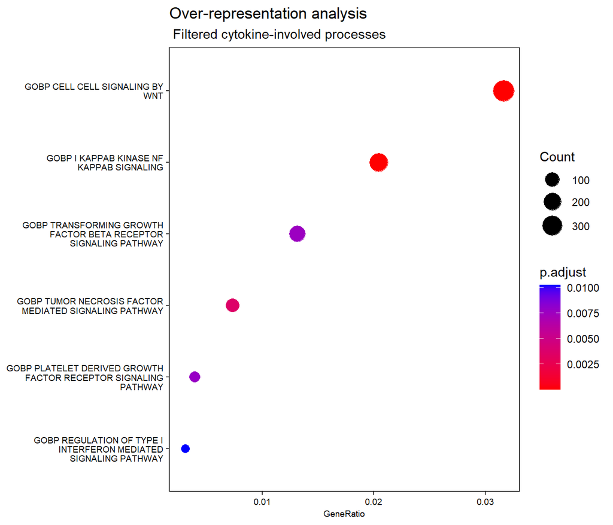

| ID | GeneRatio | p.adjust | qvalue | geneID |
| --- | --- | --- | --- | --- |
| GOBP_CELL_CELL_SIGNALING_BY_WNT | 365/11542 | 0.0000000 | 0.0000000 | DVL1/SKI/NPHP4/CTNNBIP1/MAD2L2/ARHGEF19/CDC42/WNT4/GRHL3/PTP…… |
| GOBP_I_KAPPAB_KINASE_NF_KAPPAB_SIGNALING | 236/11542 | 0.0000000 | 0.0000000 | MIB2/PLEKHG5/MUL1/PINK1/HDAC1/TRIM62/ZC3H12A/SNIP1/LURAP1/RO…… |
| GOBP_TUMOR_NECROSIS_FACTOR_MEDIATED_SIGNALING_PATHWAY | 85/11542 | 0.0035982 | 0.0024131 | TNFRSF14/TNFRSF25/HIPK1/PIAS3/TRAF5/ADAM17/LIMS1/STAT1/CASP8…… |
| GOBP_TRANSFORMING_GROWTH_FACTOR_BETA_RECEPTOR_SIGNALING_PATHWAY | 152/11542 | 0.0076147 | 0.0051067 | SKI/ZFYVE9/JUN/TGFBR3/TRIM33/BCL9/TGFB2/PARP1/SOX11/ADAM17/L…… |
| GOBP_PLATELET_DERIVED_GROWTH_FACTOR_RECEPTOR_SIGNALING_PATHWAY | 46/11542 | 0.0077924 | 0.0052259 | F3/LRIG2/TXNIP/CSRNP1/CBLB/TIPARP/APOD/PDGFRA/SNCA/PDGFC/FER…… |
| GOBP_REGULATION_OF_TYPE_I_INTERFERON_MEDIATED_SIGNALING_PATHWAY | 36/11542 | 0.0102520 | 0.0068753 | ISG15/MUL1/YTHDF2/ADAR/IKBKE/WNT5A/UBE2K/STING1/TRIM41/HSP90…… |

```
## [1] 1544    9
```

### Reactome

| ID | GeneRatio | p.adjust | qvalue |
| --- | --- | --- | --- |
| REACTOME_TRANSCRIPTIONAL_REGULATION_BY_TP53 | 351/7817 | 0.0000000 | 0.0000000 |
| REACTOME_TRANSLATION | 282/7817 | 0.0000000 | 0.0000000 |
| REACTOME_PROCESSING_OF_CAPPED_INTRON_CONTAINING_PRE_MRNA | 235/7817 | 0.0000000 | 0.0000000 |
| REACTOME_MRNA_SPLICING | 186/7817 | 0.0000000 | 0.0000000 |
| REACTOME_DNA_REPAIR | 306/7817 | 0.0000000 | 0.0000000 |
| REACTOME_CELL_CYCLE_CHECKPOINTS | 273/7817 | 0.0000000 | 0.0000000 |
| REACTOME_RHO_GTPASE_CYCLE | 403/7817 | 0.0000000 | 0.0000000 |
| REACTOME_M_PHASE | 373/7817 | 0.0000000 | 0.0000000 |
| REACTOME_S_PHASE | 158/7817 | 0.0000000 | 0.0000000 |
| REACTOME_THE_CITRIC_ACID_TCA_CYCLE_AND_RESPIRATORY_ELECTRON_TRANSPORT | 172/7817 | 0.0000000 | 0.0000000 |
| REACTOME_MITOTIC_G1_PHASE_AND_G1_S_TRANSITION | 146/7817 | 0.0000000 | 0.0000000 |
| REACTOME_RRNA_PROCESSING | 195/7817 | 0.0000000 | 0.0000000 |
| REACTOME_ANTIGEN_PROCESSING_UBIQUITINATION_PROTEASOME_DEGRADATION | 282/7817 | 0.0000000 | 0.0000000 |
| REACTOME_CLASS_I_MHC_MEDIATED_ANTIGEN_PROCESSING_PRESENTATION | 339/7817 | 0.0000000 | 0.0000000 |
| REACTOME_REGULATION_OF_TP53_ACTIVITY | 155/7817 | 0.0000000 | 0.0000000 |
| REACTOME_MITOTIC_METAPHASE_AND_ANAPHASE | 220/7817 | 0.0000000 | 0.0000000 |
| REACTOME_RESPIRATORY_ELECTRON_TRANSPORT_ATP_SYNTHESIS_BY_CHEMIOSMOTIC_COUPLING_AND_HEAT_PRODUCTION_BY_UNCOUPLING_PROTEINS | 125/7817 | 0.0000000 | 0.0000000 |
| REACTOME_RESPIRATORY_ELECTRON_TRANSPORT | 103/7817 | 0.0000000 | 0.0000000 |
| REACTOME_INFLUENZA_INFECTION | 151/7817 | 0.0000000 | 0.0000000 |
| REACTOME_DISEASES_OF_SIGNAL_TRANSDUCTION_BY_GROWTH_FACTOR_RECEPTORS_AND_SECOND_MESSENGERS | 380/7817 | 0.0000000 | 0.0000000 |
| REACTOME_PROGRAMMED_CELL_DEATH | 194/7817 | 0.0000000 | 0.0000000 |
| REACTOME_MITOTIC_SPINDLE_CHECKPOINT | 109/7817 | 0.0000000 | 0.0000000 |
| REACTOME_SYNTHESIS_OF_DNA | 117/7817 | 0.0000000 | 0.0000000 |
| REACTOME_NUCLEOTIDE_EXCISION_REPAIR | 108/7817 | 0.0000000 | 0.0000000 |
| REACTOME_CELLULAR_RESPONSE_TO_STARVATION | 149/7817 | 0.0000000 | 0.0000000 |
| REACTOME_MITOTIC_PROMETAPHASE | 188/7817 | 0.0000000 | 0.0000000 |
| REACTOME_ORGANELLE_BIOGENESIS_AND_MAINTENANCE | 265/7817 | 0.0000000 | 0.0000000 |
| REACTOME_PTEN_REGULATION | 133/7817 | 0.0000000 | 0.0000000 |
| REACTOME_APOPTOSIS | 167/7817 | 0.0000000 | 0.0000000 |
| REACTOME_SIGNALING_BY_ROBO_RECEPTORS | 199/7817 | 0.0000000 | 0.0000000 |

[output cut: 441 more lines]

```
## [1] 471   9
```

#### Filtered for relevant terms

. . .

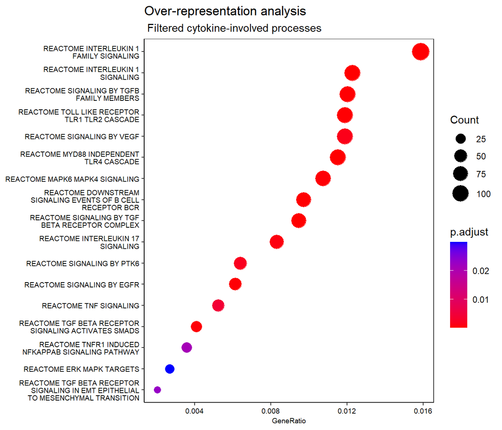

| ID | GeneRatio | p.adjust | qvalue | geneID |
| --- | --- | --- | --- | --- |
| REACTOME_SIGNALING_BY_TGF_BETA_RECEPTOR_COMPLEX | 74/7817 | 0.0000001 | 0.0000000 | PRKCZ/SKI/HDAC1/ZFYVE9/TRIM33/CGN/F11R/UCHL5/PARP1/PPP1CB/RP…… |
| REACTOME_INTERLEUKIN_1_SIGNALING | 96/7817 | 0.0000014 | 0.0000008 | PSMB2/PSMA5/PSMD4/PSMB4/S100A12/PSME4/RPS27A/PELI1/IL1R2/IL1…… |
| REACTOME_MYD88_INDEPENDENT_TLR4_CASCADE | 90/7817 | 0.0000157 | 0.0000090 | RPS6KA1/JUN/S100A12/IKBKE/MAPKAPK2/RPS27A/TANK/ATF2/CASP8/CR…… |
| REACTOME_DOWNSTREAM_SIGNALING_EVENTS_OF_B_CELL_RECEPTOR_BCR | 76/7817 | 0.0000294 | 0.0000168 | PSMB2/BCL10/PSMA5/NRAS/PSMD4/PSMB4/RASGRP3/PSME4/RPS27A/REL/…… |
| REACTOME_INTERLEUKIN_1_FAMILY_SIGNALING | 124/7817 | 0.0000797 | 0.0000455 | PSMB2/PSMA5/PSMD4/PSMB4/S100A12/PTPN14/PSME4/RPS27A/PELI1/IL…… |
| REACTOME_SIGNALING_BY_TGFB_FAMILY_MEMBERS | 94/7817 | 0.0001243 | 0.0000709 | PRKCZ/SKI/HDAC1/ZFYVE9/TRIM33/CGN/F11R/UCHL5/PARP1/PPP1CB/RP…… |
| REACTOME_TOLL_LIKE_RECEPTOR_TLR1_TLR2_CASCADE | 93/7817 | 0.0001480 | 0.0000844 | RPS6KA1/JUN/S100A9/S100A12/S100A8/MAPKAPK2/RPS27A/PELI1/ATF2…… |
| REACTOME_SIGNALING_BY_EGFR | 48/7817 | 0.0002496 | 0.0001424 | CDC42/EPS15/NRAS/SHC1/ADAM17/SOS1/RPS27A/TGFA/STAM2/AAMP/LRI…… |
| REACTOME_MAPK6_MAPK4_SIGNALING | 84/7817 | 0.0003064 | 0.0001749 | CDC42/PSMB2/AGO4/AGO1/AGO3/JUN/PRKACB/CDC14A/PSMA5/MOV10/PSM…… |
| REACTOME_TGF_BETA_RECEPTOR_SIGNALING_ACTIVATES_SMADS | 32/7817 | 0.0003283 | 0.0001874 | ZFYVE9/UCHL5/PPP1CB/RPS27A/XPO1/TGFBR2/SMURF1/TGFBR1/BAMBI/PPP1CA/CBL/STRAP/USP15/PPP1CC/UBC/NEDD8/SMAD3/FURIN/STUB1/UBB/MTMR4/SMURF2/SMAD2/SMAD7/SMAD4/NEDD4L/UBA52/TGFB1/PPP1R15A/UBE2M/FKBP1A/PMEPA1 |
| REACTOME_INTERLEUKIN_17_SIGNALING | 65/7817 | 0.0007306 | 0.0004169 | RPS6KA1/JUN/MAPKAPK2/RPS27A/ATF2/CREB1/IL17RE/IL17RC/IRAK2/M…… |
| REACTOME_SIGNALING_BY_VEGF | 93/7817 | 0.0014346 | 0.0008186 | PRKCZ/MTOR/CDC42/WASF2/PRKACB/VAV3/AHCYL1/NRAS/THEM4/NCF2/MA…… |
| REACTOME_SIGNALING_BY_PTK6 | 50/7817 | 0.0019315 | 0.0011022 | KHDRBS1/SFPQ/NRAS/EPAS1/RPS27A/DOK1/ERBB4/RHOA/EREG/BTC/EGF/…… |
| REACTOME_TNF_SIGNALING | 41/7817 | 0.0041701 | 0.0023795 | OTUD7B/USP21/ADAM17/RPS27A/CFLAR/CASP8/USP4/OTULIN/RACK1/RIP…… |
| REACTOME_TNFR1_INDUCED_NFKAPPAB_SIGNALING_PATHWAY | 28/7817 | 0.0210817 | 0.0120298 | OTUD7B/USP21/RPS27A/USP4/RACK1/RIPK1/TNF/MAP3K7/TNFAIP3/TAB2/IKBKB/SHARPIN/TRAF1/TRAF2/CHUK/BIRC3/BIRC2/USP2/TNFRSF1A/UBC/CYLD/TRADD/UBB/UBA52/RBCK1/TAB1/TAB3/XIAP |
| REACTOME_TGF_BETA_RECEPTOR_SIGNALING_IN_EMT_EPITHELIAL_TO_MESENCHYMAL_TRANSITION | 16/7817 | 0.0228788 | 0.0130552 | PRKCZ/CGN/F11R/RPS27A/TGFBR2/RHOA/SMURF1/TGFBR1/PARD3/UBC/PARD6A/UBB/ARHGEF18/UBA52/TGFB1/FKBP1A |
| REACTOME_ERK_MAPK_TARGETS | 21/7817 | 0.0299896 | 0.0171128 | RPS6KA1/DUSP7/PPP2CA/MAPK14/PPP2R5D/RPS6KA2/DUSP4/PPP2CB/PPP2R1B/DUSP6/RPS6KA5/MEF2A/MAPK3/MAPK7/DUSP3/VRK3/PPP2R1A/MAPK1/MAPK11/RPS6KA3/ELK1 |

```
## [1] 471   9
```

# What I’ve found to be expressed in HBE1, control

- GROa / CXCL1: CXCR1 and CXCR2 are expressed (CXCR1 in 1/3 samples, CXCR2 in 2 out of 3)
- IL17a: IL17RA-E are expressed
- IL6: IL6ST, a signal transducer, is expressed
- IL8: CXCR1 and CXCR2 are expressed (CXCR1 in 1/3 samples, CXCR2 in 2 out of 3)
- MCP1: is known to activate NFkB and ERK signaling, which both express lots of transcripts (cfr reactome results)
- MIP3a / CCL6: CCR6 is not expressed but there is known crosstalk with the IL17 pathway and the TLRs (cfr reactome results)

NB: CCR4, CCR6 are not expressed in any samples, their count is at 0 across conditions.

| gene | Avrg_FPKM | sd_FPKM |
| --- | --- | --- |
| AXL | 0.0647287 | 0.0241616 |
| BAMBI | 0.2550862 | 0.1555485 |
| CD14 | 0.2459399 | 0.2152048 |
| CXCL1 | 5.1177893 | 0.6040960 |
| CXCL11 | 0.0566408 | 0.0981047 |
| CXCL14 | 15.3061824 | 3.7180180 |
| CXCL16 | 0.2114323 | 0.0259774 |
| CXCL17 | 0.0073913 | 0.0128021 |
| CXCL2 | 1.7058956 | 0.4130350 |
| CXCL3 | 0.6214562 | 0.2783868 |
| CXCL6 | 0.5424930 | 0.4000834 |
| CXCR1 | 0.0263034 | 0.0455588 |
| CXCR2 | 0.0341094 | 0.0323343 |
| EGFR | 1.1192497 | 0.2698598 |
| FLT1 | 0.0005566 | 0.0009641 |
| IL17RA | 0.3340565 | 0.1837355 |
| IL17RB | 0.1090206 | 0.0097164 |
| IL17RC | 0.0285966 | 0.0250229 |
| IL17RD | 0.0124836 | 0.0083703 |
| IL17RE | 6.2308996 | 4.1306746 |
| IL1R1 | 0.0740407 | 0.0232382 |
| IL1RN | 2.9980420 | 0.8565997 |
| IL6R | 0.5139261 | 0.1637566 |
| IL6ST | 1.0649781 | 0.1276876 |
| KDR | 0.0051732 | 0.0045612 |
| NRP1 | 0.0694865 | 0.0224544 |
| NRP2 | 0.2225745 | 0.0512937 |
| TGFBR1 | 0.8159491 | 0.0934725 |
| TNFRSF1A | 1.2158833 | 0.4493086 |
| TRAF7 | 1.2358894 | 0.2362252 |
| TRAP1 | 1.6789611 | 0.5623813 |
| VEGFA | 4.7231519 | 1.1266344 |
| VEGFB | 1.4616291 | 0.6781360 |
| VEGFD | 0.0034859 | 0.0060377 |

My additions to cytokines of interest which I have found receptors for:

- TNFa: TNFRSF1A, TNFRSF2A
- IL1: IL1R1, IL1RB, IL1RN
- TGFb: TGFBR1, TGBR2, BAMBI
- LPS: CD14
- VEGF: NRP1, NRP2, KDR, VEGFR2, FLT1, VEGFA, VEGFB, VEGFD
- GAS6: AXL
- EGF: EGFR